# Take-home Exercise 1

This is the first take-home exercise in a series of take-home exercises for the Visual Analytics module.In this exercise, we will reveal the demographic of the city of Engagement.

Tianyue Sui https://example.com/norajones (MITB, Singapore Management University)https://scis.smu.edu.sg/  
2022-05-26

# 1 Overview

In this take-home exercise, appropriate static statistical graphics methods are used to reveal demographic of the city of Engagement, Ohio USA.

# 2 Getting Started

Before we get started, it is important for us to ensure that the required R packages have been installed. If yes, we will load the R packages. If they have yet to be installed, we will install the R packages and load them onto R environment.

The chunk code below will do the trick.

```r
packages = c('tidyverse','rvest','reshape2','ggtern','viridis','ggrepel','ggpubr','ggmosaic','stringr','lubridate','ggthemes','ggplot2')
for(p in packages){
  if(!require(p, character.only =T)){
    install.packages(p)
  }
  library(p, character.only =T)
}
```

# 3 Importing Data

The code chunk below import *Participants.csv* and *Jobs.csv* from the data folder into R by using [`read_csv()`](https://readr.tidyverse.org/reference/read_delim.html) of [**readr**](https://readr.tidyverse.org/index.html) and save it as a tibble data frame called *participants*and *jobs*.

```r
participants <- read_csv("data/Participants.csv")
jobs <- read_csv("data/Jobs.csv")
```

# 4 Data Preparation

### 4.1 Add readable score and indicators for Joy Degree and Age range

```r
participants$Score<-(participants$joviality * 100)
participants$J_Degree <- cut(participants$Score, breaks = c(0,20,40,60,80,100), labels = c("Strongly Sad","Sad","Neutral","Happy","Strongly Happy"))
participants$Age_range <- cut(participants$age, breaks = c(17,30,40,50,60),labels = c("18-30","30-40","40-50","50-60"))
```

### 4.2 Identify working days to regular work day and weekends

```r
jobs$Sat<-0
jobs$Sun<-0
jobs$iden_we<-0
jobs$Sat[which(str_detect(jobs$daysToWork,"Saturday"))]<-1
jobs$Sun[which(str_detect(jobs$daysToWork,"Sunday"))]<-1
jobs$we_num <-jobs$Sat + jobs$Sun

jobs$wd<-0
jobs$wd<-lengths(c(strsplit(jobs$daysToWork,",")))
jobs$iden_we<-"test"
jobs$iden_we[which(jobs$we_num ==2)]<-"Work 2 Days"
jobs$iden_we[which(jobs$we_num ==1)]<-"Work 1 Day"
jobs$iden_we[which(jobs$we_num == 0)]<-"Not Work"
```

# 5 Final Visualization

### 5.1 Overall distribution of Joviality

Below histogram and density chart showed tend is that more participants chose Joy score less than 25.

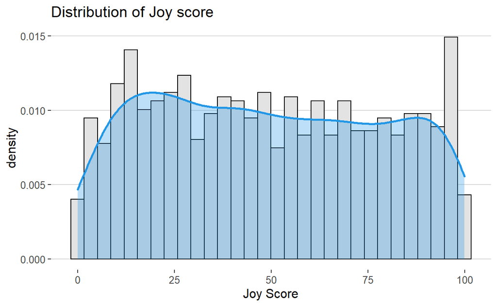

```r
ggplot(participants, aes(x = Score)) +
  geom_histogram(aes(y = ..density..),
                 colour = 1, fill = "grey89") +
  geom_density(lwd = 1, colour = 4,
               fill = 4, alpha = 0.3) +
  theme_hc() + labs(x="Joy Score", title = "Distribution of Joy score")
```

### 5.2 Joviality median exposed a great volatility among Interest Group having kids when compared with not having kids

The median of Joy score of Interest Group not having kids is almost stablised at 50, while for having kids portion, we saw a great volatility. The code chunk below plot a boxplot char by using geom_boxplot()

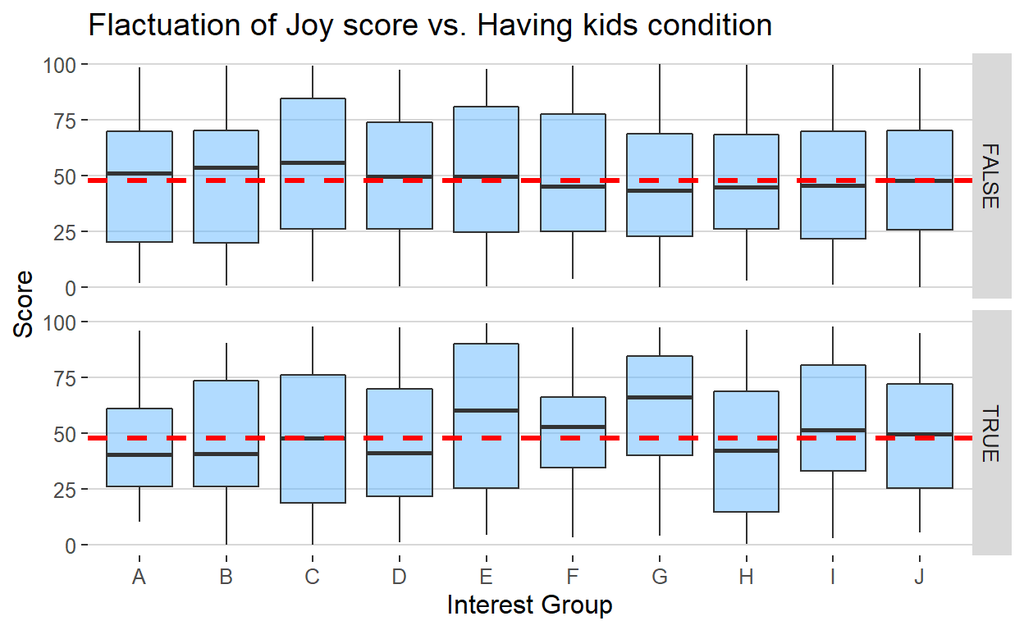

```r
ggplot(data=participants,aes(y = Score, x = interestGroup)) +
  geom_boxplot(fill = "steelblue1",alpha=0.5) + facet_grid(haveKids ~.) +
  geom_hline(aes(yintercept=median(Score)),color="red",linetype="dashed",size = 1.2) +
  theme_hc()+ labs(x="Interest Group", title = "Flactuation of Joy score vs. Having kids condition")
```

### 5.3 Participants who have kids are far fewer than Participants have kids in different education

As both Educational level and Kid status are categorical data, we chose mosaic graph to display. The code chunk below plot a mosaic char by using geom_mosaic()

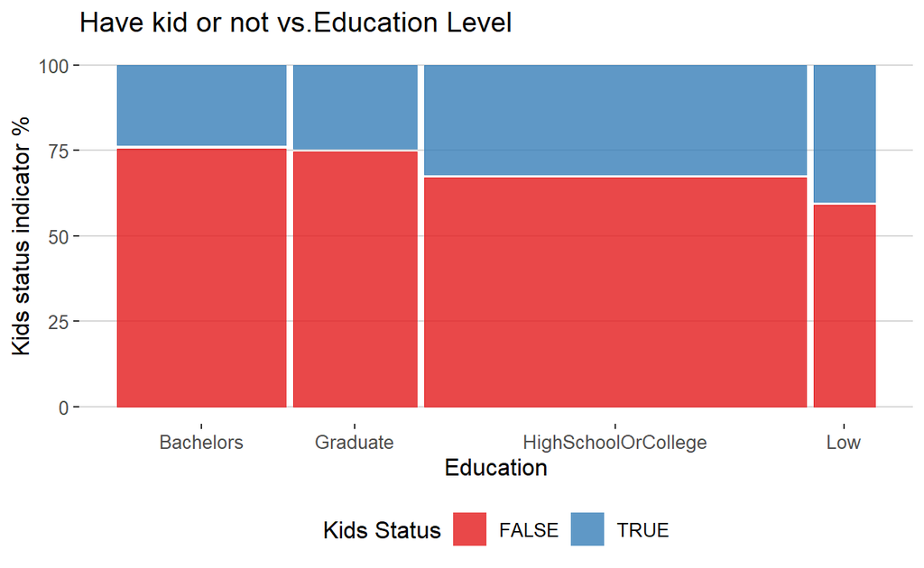

```r
ggplot(data = participants) +
  geom_mosaic(aes(x = product(educationLevel), fill = haveKids)) +
  labs(y="Kids status indicator %", x="Education", title = "Have kid or not vs.Education Level") +
  scale_y_continuous(labels = c(0,25,50,75,100)) +
  scale_fill_brewer(palette = "Set1", name = "Kids Status") +
  theme_hc()
```

The code chunk below plot a density char by using geom_density()

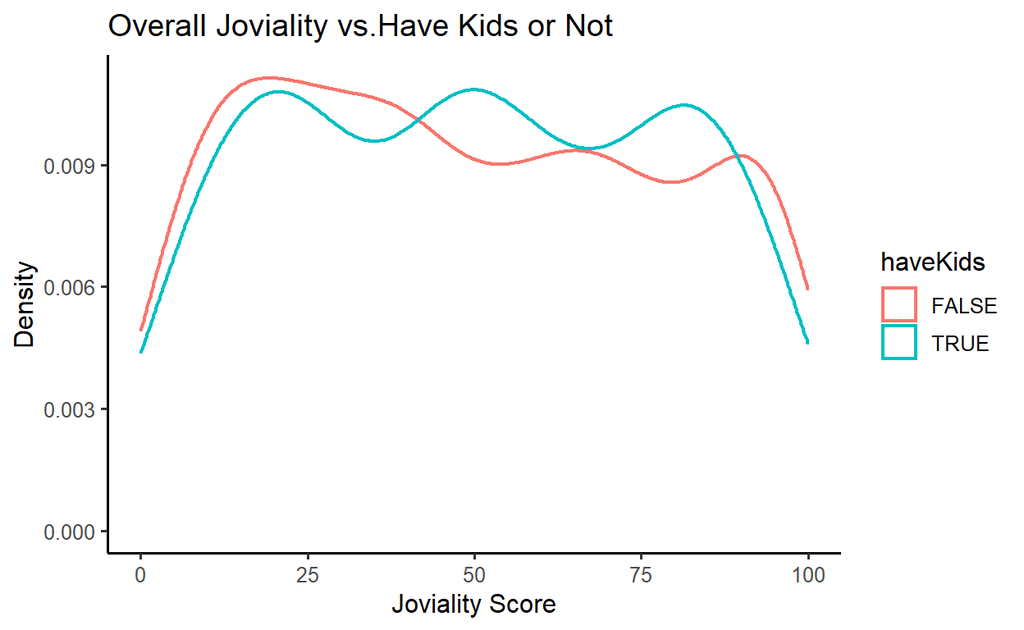

```r
ggplot(data=participants,aes(x = Score,colour = haveKids)) +geom_density(lwd=0.8) +
  labs(y="Density", x="Joviality Score", title = "Overall Joviality vs.Have Kids or Not") +
  theme_classic2()
```

### 5.5 Having kids impact joviality among different education degree

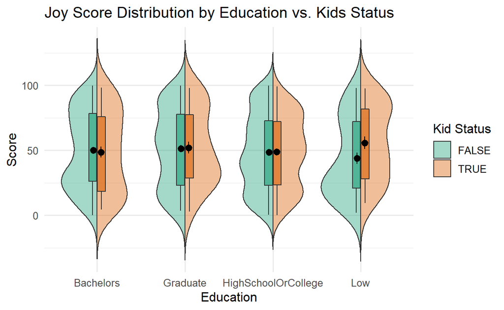

```r
ggplot(participants, aes(x = educationLevel, y = Score, fill = haveKids)) +
  introdataviz::geom_split_violin(alpha = .4, trim = FALSE) +
  geom_boxplot(width = .2, alpha = .6, fatten = NULL, show.legend = FALSE) +
  stat_summary(fun.data = "mean_se", geom = "pointrange", show.legend = F,
               position = position_dodge(.175)) +
  scale_x_discrete(name = "Education", labels = c("Bachelors", "Graduate","HighSchoolOrCollege","Low")) +
  scale_fill_brewer(palette = "Dark2", name = "Kid Status") +
  theme_minimal()+labs(title="Joy Score Distribution by Education vs. Kids Status")
```

### 5.6 Participants without kids are fewer in age range 30-50 comparing with the having kids ones

Below violin chart showed the trend of participants in different ages. There is slightly different between age 30-50, which showed participant not having kids is fewer than participant having kids.

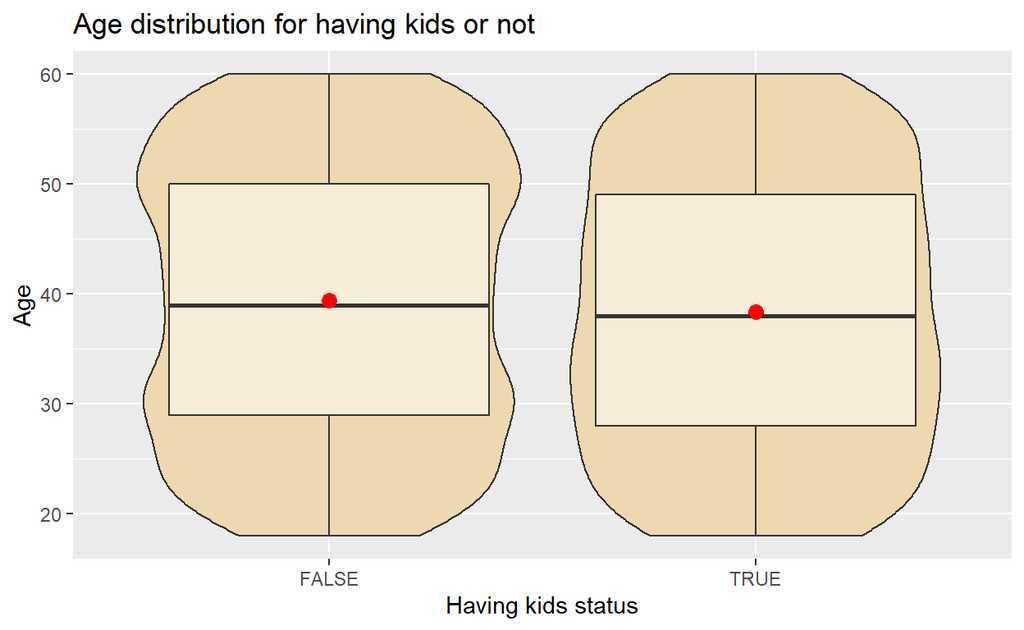

```r
ggplot(data=participants,aes(y = age, x= haveKids)) +geom_violin(fill= "wheat2") +
  geom_boxplot(alpha=0.5) +
  stat_summary(geom ="point",fun.y="mean", color="red", size=3)+
  labs(y="Age",x="Having kids status", title = "Age distribution for having kids or not")
```

### 5.7 Hourly rate by education

In general, a higher hourly rate is conneted with a higher education level. Below code chunk shows boxplot char by using geom_boxplot(). To be specific, the hourly rate of participants who get Graduate level, is far more than other levels and vice versa.

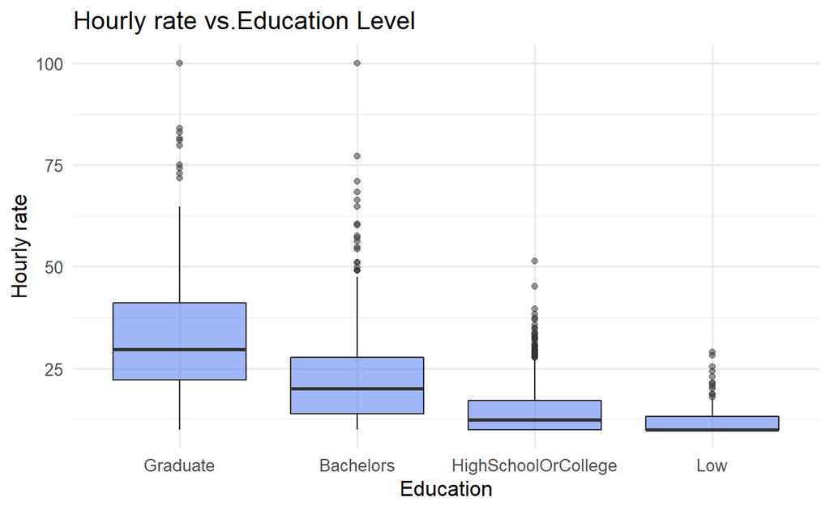

```r
jobs$rate_edu <- factor(jobs$educationRequirement,levels = c("Graduate", "Bachelors","HighSchoolOrCollege","Low"))
ggplot(data=jobs,aes(y = hourlyRate, x= rate_edu)) + geom_boxplot(fill = "royalblue2",alpha= 0.5)+
labs(x="Education", y="Hourly rate", title = "Hourly rate vs.Education Level") +
theme_minimal()
```

### 5.8 Working on weekends by education requirement

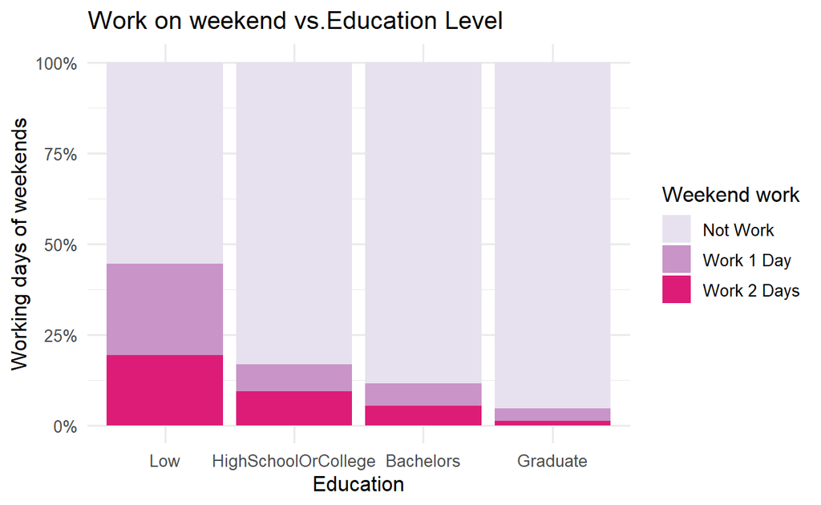

```r
ggplot(jobs, aes(fill= iden_we, y=wd, x=educationRequirement_weekend)) +
  geom_bar(position="fill", stat="identity") +
  scale_fill_brewer(palette = "PuRd", name = "Weekend work") +
  labs(y="Working days of weekends",x="Education", title = "Work on weekend vs.Education Level") +
  scale_y_continuous(labels = scales::percent) +
  theme_minimal()
```